# Proj

Methods

Replicate Analysis

Overview of all groups

Parent Trees

F1 Analysis

Mānuka background(cultural,uses,industry)

Experimental Cross Design

Two east cape parents, F1 cross siblings

#### Methods

Two parental trees from the East Cape region of New Zealand were bred together to produce a full sibling F1 generation, all of which are located at Plant and Food Research in Palmerston North. All of the trees have undergone full genome sequences and markers developed and mapped.

#### F1 Layout

Map indicates the layout of the F1 generation resulting from a cross between EC201 and EC103 parents. Column 1 is approximately lengthways facing north.

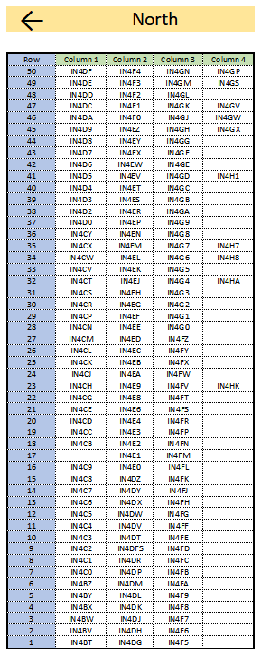

“Map of F1 Trees”

#### Height Diagram

Diagram indicates the areas of leaf collection regarding height. Each Tree generally had 10 leaves collected (some trees have been sampled more than once), leaves were selected from low, mid and high points of the tree. The first leaf sampled from each tree was measured twice for replication comparison.

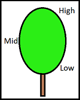

“Diagram of leaf collection levels”

#### Import and Arrange Data

Dualex was used to measure transmittance through all samples included in this dataset, more information on how this works can be found in Clara Rey Caramés, 2015.

- Surface content of chlorophyll in $g/cm^2$ (Chl)
- Epidermal Flavoid content in absorbance units(Au); Flavonol(Flav) and Anthocyanin(Anth)
- Nitrogen Balance Index status is calculated using Chlorophyll and Flavonol values automatically (NBI)

It also contains information about the block position, the leaf height information, and presense or absence of flowering

Sheet “Dup” contains only the replicated samples

#### Replicate Analysis

Replicates exist in two groups; first leaf measurement (Y1), and the second leaf measurement (Y2). The second measurement was taken after removing the leaf following the first reading, to help establish the presence of any bias introduced by the Dualex.

#### Replicate Plots and Data Overview Plots of replicate measure disitributions, medians (lines), means (empty diamonds)

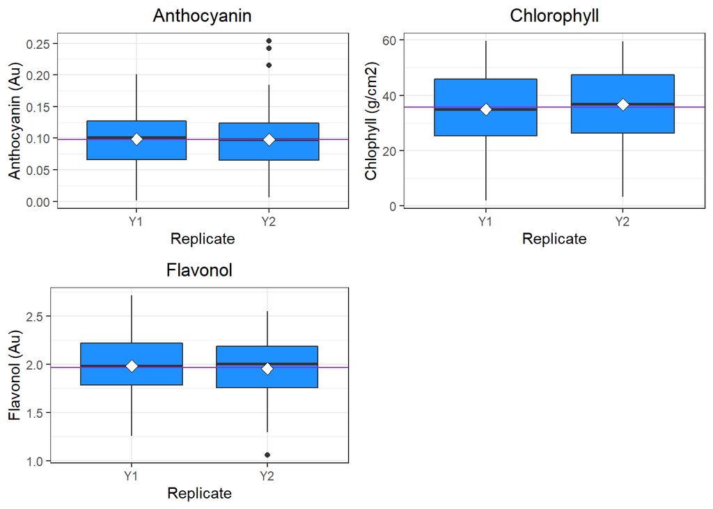

#### Data Distribution of replicates

```
##   Rep.   AnthMean     AnthSD  ChlMean    ChlSD FlavMean    FlavSD
## 1   Y1 0.09830189 0.04539806 34.93672 14.55641 1.979969 0.2863768
## 2   Y2 0.09768153 0.04439018 36.59920 14.51963 1.954280 0.2796720
```

#### Replicate ANOVAs

```
## Analysis of Variance Table
##
## Response: Dup$Anth
##            Df  Sum Sq   Mean Sq F value Pr(>F)
## Dup$Rep.    1 0.00003 0.0000304  0.0151 0.9023
## Residuals 314 0.63303 0.0020160
```

```
## Analysis of Variance Table
##
## Response: Dup$Chl
##            Df Sum Sq Mean Sq F value Pr(>F)
## Dup$Rep.    1    218  218.33   1.033 0.3102
## Residuals 314  66366  211.36
```

```
## Analysis of Variance Table
##
## Response: Dup$Flav
##            Df  Sum Sq  Mean Sq F value Pr(>F)
## Dup$Rep.    1  0.0521 0.052129  0.6506 0.4205
## Residuals 314 25.1596 0.080126
```

The replicate data and ANOVAs appear to support the reliability of the dualex, thus we can confidently continue our analysis with some outlier removal.

#### Overview of all groups

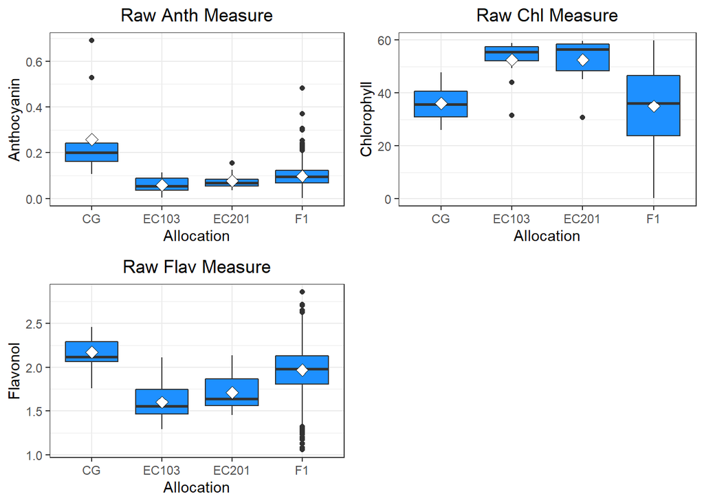

As expected we have a large distribution contained within the F1 group. Parental samples indicate they are fairly similiar which could prove to complicate our analysis. The Crimson Glory outgroup appears distinctive from the parental trees and sometimes seems to correlate with the F1 population.

#### Data Summary

```
##   Allocation   AnthMean     AnthSD  ChlMean     ChlSD FlavMean    FlavSD
## 1         CG 0.25763636 0.18306079 36.02836  7.090510 2.169455 0.2021457
## 2      EC103 0.05883333 0.03576650 52.59242  7.889391 1.599833 0.2334250
## 3      EC201 0.07790000 0.03665288 52.60670  9.291990 1.710800 0.2217590
## 4         F1 0.09711830 0.04437066 34.99601 15.144271 1.967003 0.2479930
```

Anthocyanin Crimson Glory(CG) outgroup apparent, F1 population more similar to parental trees.

Chlorophyll F1 very diverse, overlaps with both parent trees and outgroup, more similar median and distrubtion to outgroup.

#### Allocation Anovas and parental comparison

```
## Analysis of Variance Table
##
## Response: Data$Anth
##                   Df Sum Sq  Mean Sq F value    Pr(>F)
## Data$Allocation    3 0.3040 0.101343  47.474 < 2.2e-16 ***
## Residuals       1821 3.8873 0.002135
## ---
## Signif. codes:  0 '***' 0.001 '**' 0.01 '*' 0.05 '.' 0.1 ' ' 1
```

```
## Analysis of Variance Table
##
## Response: Data$Chl
##                   Df Sum Sq Mean Sq F value    Pr(>F)
## Data$Allocation    3   6742 2247.21  9.9149 1.748e-06 ***
## Residuals       1821 412728  226.65
## ---
## Signif. codes:  0 '***' 0.001 '**' 0.01 '*' 0.05 '.' 0.1 ' ' 1
```

```
## Analysis of Variance Table
##
## Response: Data$Flav
##                   Df  Sum Sq Mean Sq F value    Pr(>F)
## Data$Allocation    3   2.713 0.90423  14.755 1.708e-09 ***
## Residuals       1821 111.598 0.06128
## ---
## Signif. codes:  0 '***' 0.001 '**' 0.01 '*' 0.05 '.' 0.1 ' ' 1
```

#### Parent Trees

```
## Analysis of Variance Table
##
## Response: Parent$Anth
##                Df    Sum Sq   Mean Sq F value Pr(>F)
## Parent$Tree.ID  1 0.0019829 0.0019829  1.5159 0.2325
## Residuals      20 0.0261626 0.0013081
```

```
## Analysis of Variance Table
##
## Response: Parent$Chl
##                Df Sum Sq Mean Sq F value Pr(>F)
## Parent$Tree.ID  1    0.0   0.001       0 0.9969
## Residuals      20 1461.7  73.087
```

```
## Analysis of Variance Table
##
## Response: Parent$Flav
##                Df  Sum Sq  Mean Sq F value Pr(>F)
## Parent$Tree.ID  1 0.06717 0.067165  1.2892 0.2696
## Residuals      20 1.04195 0.052098
```

[output not shown]

It appears as if there is no statistical difference between the parents, which may complicate or prevent the analysis.

#### F1 Analysis

#### Unadjusted F1 chemical distributions

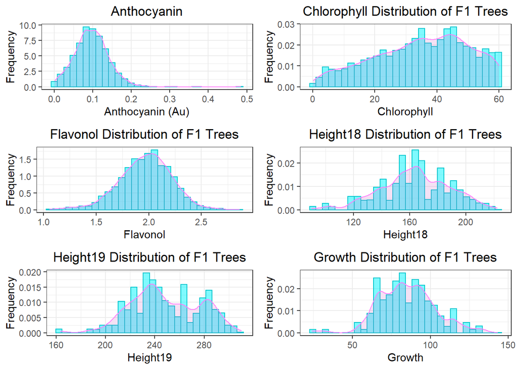

Anothcyanin left bias, long tail

Chlorophyll right bias, truncated

Flavonol typical bell curve with slightly long tails both directions

Height 2018 lumpy normal disitribution

Height 2019 appears to be two overlapping distribitiuons, maybe 3

Growth maybe 3 overlapping populations

#### Row Comparisons

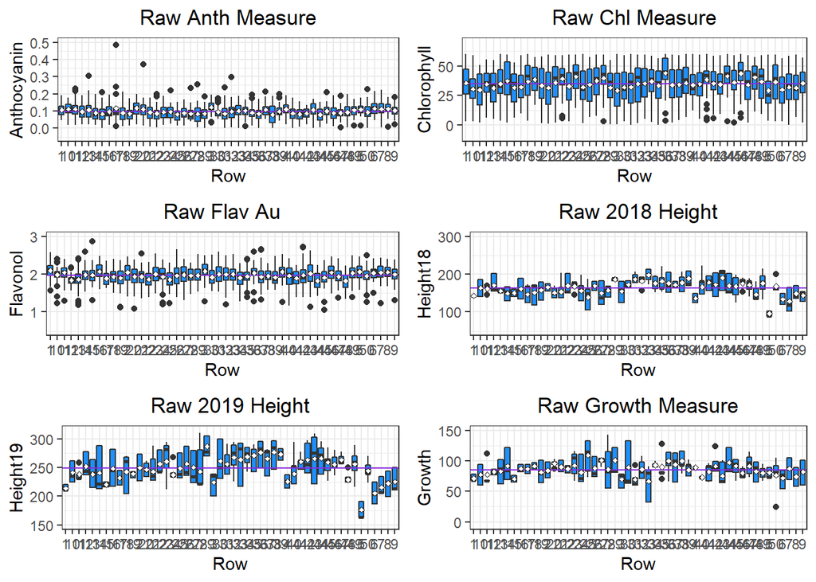

#### Column Comparisons

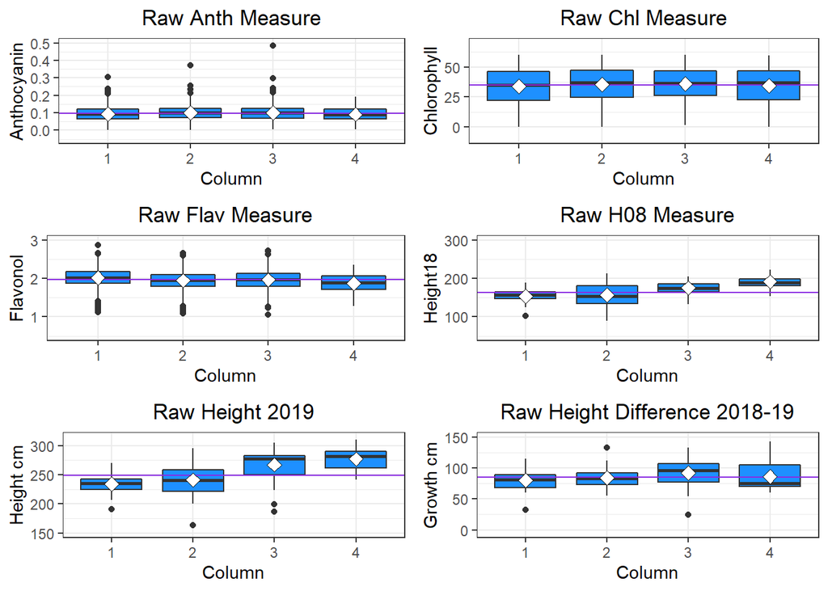

#### Row v Column Heatmaps

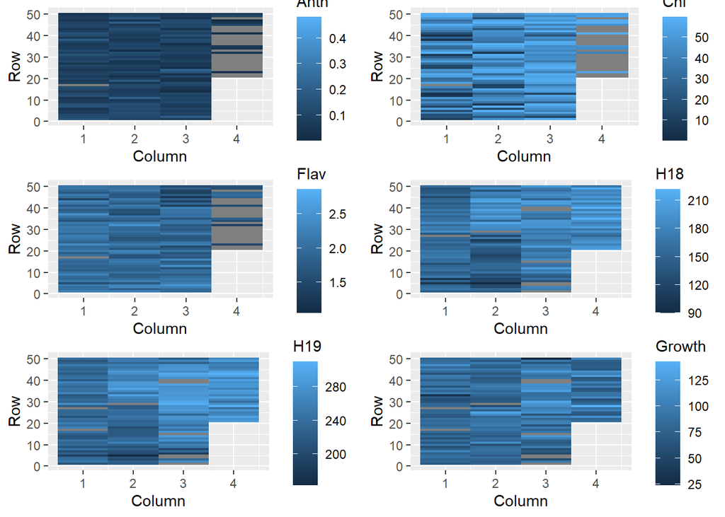

#### Height Plots

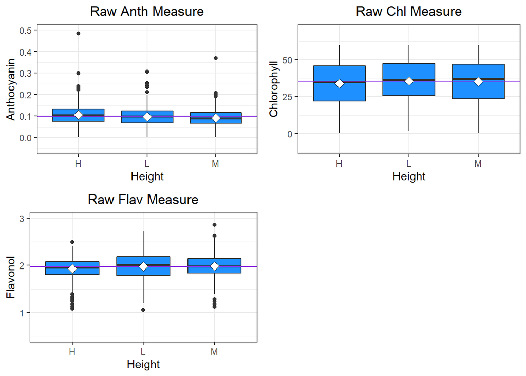

#### ANOVAs comparing Height, Row and Columns for each chemical

```
## Analysis of Variance Table
##
## Response: F1$Anth
##             Df Sum Sq  Mean Sq F value    Pr(>F)
## F1$Row       1 0.0668 0.066767 35.0627 3.820e-09 ***
## F1$Column    1 0.0042 0.004242  2.2279    0.1357
## F1$Height    2 0.0522 0.026106 13.7094 1.234e-06 ***
## Residuals 1787 3.4028 0.001904
## ---
## Signif. codes:  0 '***' 0.001 '**' 0.01 '*' 0.05 '.' 0.1 ' ' 1
```

```
## Analysis of Variance Table
##
## Response: F1$Anth
##             Df Sum Sq  Mean Sq F value    Pr(>F)
## F1$Row       1 0.0668 0.066767  35.038 3.867e-09 ***
## F1$Height    2 0.0521 0.026072  13.682 1.267e-06 ***
## Residuals 1788 3.4071 0.001906
## ---
## Signif. codes:  0 '***' 0.001 '**' 0.01 '*' 0.05 '.' 0.1 ' ' 1
```

```
## Analysis of Variance Table
##
## Response: F1$Chl
##             Df Sum Sq Mean Sq F value   Pr(>F)
## F1$Row       1   5558  5557.6 24.5835 7.79e-07 ***
## F1$Column    1    394   393.6  1.7409   0.1872
## F1$Height    2    828   414.2  1.8321   0.1604
## Residuals 1787 403984   226.1
## ---
## Signif. codes:  0 '***' 0.001 '**' 0.01 '*' 0.05 '.' 0.1 ' ' 1
```

```
## Analysis of Variance Table
##
## Response: F1$Chl
##             Df Sum Sq Mean Sq F value    Pr(>F)
## F1$Row       1   5558  5557.6   24.55 7.921e-07 ***
## Residuals 1790 405206   226.4
## ---
## Signif. codes:  0 '***' 0.001 '**' 0.01 '*' 0.05 '.' 0.1 ' ' 1
```

```
## Analysis of Variance Table
##
## Response: F1$Flav
##             Df  Sum Sq Mean Sq F value    Pr(>F)
## F1$Row       1   1.377 1.37745 23.0843 1.680e-06 ***
## F1$Column    1   1.209 1.20913 20.2635 7.183e-06 ***
## F1$Height    2   0.930 0.46482  7.7898 0.0004281 ***
## Residuals 1787 106.631 0.05967
## ---
## Signif. codes:  0 '***' 0.001 '**' 0.01 '*' 0.05 '.' 0.1 ' ' 1
```

```
## Analysis of Variance Table
##
## Response: F1$H18
##             Df Sum Sq Mean Sq F value    Pr(>F)
## F1$Row       1 190041  190041  465.42 < 2.2e-16 ***
## F1$Column    1 155091  155091  379.82 < 2.2e-16 ***
## Residuals 1721 702727     408
## ---
## Signif. codes:  0 '***' 0.001 '**' 0.01 '*' 0.05 '.' 0.1 ' ' 1
```

```
## Analysis of Variance Table
##
## Response: as.numeric(F1$H19)
##             Df Sum Sq Mean Sq F value    Pr(>F)
## F1$Row       1 264274  264274  608.03 < 2.2e-16 ***
## F1$Column    1 304495  304495  700.56 < 2.2e-16 ***
## Residuals 1720 747587     435
## ---
## Signif. codes:  0 '***' 0.001 '**' 0.01 '*' 0.05 '.' 0.1 ' ' 1
```

```
## Analysis of Variance Table
##
## Response: as.numeric(F1$Growth)
##             Df Sum Sq Mean Sq F value    Pr(>F)
## F1$Row       1   6073  6073.3  19.996 8.268e-06 ***
## F1$Column    1  24791 24790.5  81.621 < 2.2e-16 ***
## Residuals 1720 522411   303.7
## ---
## Signif. codes:  0 '***' 0.001 '**' 0.01 '*' 0.05 '.' 0.1 ' ' 1
```

Anthocyanin Significant Row and Height effects

Chlorophyll Significant Row effect

Flavonol Significant row,column and height effects

Height 2018 Very Significant effect of row and column

Height 2019 Very Significant effect of row and column

Growth difference (Height 2019- Height 2018) Very Significant effect of row and column - need to double check might be from later in analysis

#### Adjusting Row, Column and Height measures

```
##      Height Column Row Tree.ID Allocation Rep. measure Flower Flower.Level
## 115       H      3  17   IN4FM         F1    N      11      N            0
## 1293      M      2  20   IN4E4         F1    N       7      N            0
##         Chl  Flav  Anth   NBI Height08 Height09 H19 H18 Growth AnthRowMeans
## 115  59.122 1.640 0.483 36.05      166      245 245 166     79    0.1163182
## 1293 18.511 1.401 0.370 13.21      138      234 234 138     96    0.1105227
##      ChlRowMeans FlavRowMeans H18RowMeans H19RowMeans AnthColMeans ChlColMeans
## 115     32.12650     1.886773    146.6957       232.0   0.09897588    36.04402
## 1293    31.51561     1.933068    151.0000       246.5   0.09924281    35.39257
##      FlavColMeans H18ColMeans H19ColMeans AnthHeightMeans ChlHeightMeans
## 115      1.960649    175.1734    267.4482      0.10500200       33.90735
## 1293     1.944405    157.0018    241.0717      0.09133645       35.25540
##      FlavHeightMeans
## 115         1.930788
## 1293        1.983505
```

```
## Analysis of Variance Table
##
## Response: F1$AdjAnth
##             Df  Sum Sq    Mean Sq F value Pr(>F)
## F1$Row       1 0.00008 0.00007760  0.0456 0.8310
## F1$Colum     1 0.00122 0.00121623  0.7144 0.3981
## F1$Height    2 0.00018 0.00008959  0.0526 0.9487
## Residuals 1785 3.03876 0.00170238
```

```
## Analysis of Variance Table
##
## Response: F1$AdjChl
##             Df Sum Sq Mean Sq F value Pr(>F)
## F1$Row       1      4    3.73  0.0172 0.8956
## F1$Column    1     75   75.45  0.3490 0.5547
## F1$Height    2    788  394.21  1.8235 0.1618
## Residuals 1785 385880  216.18
```

```
## Analysis of Variance Table
##
## Response: F1$AdjFlav
##             Df Sum Sq  Mean Sq F value Pr(>F)
## F1$Row       1  0.045 0.044969  0.8139 0.3671
## F1$Column    1  0.005 0.005313  0.0962 0.7565
## F1$Height    2  0.001 0.000440  0.0080 0.9921
## Residuals 1785 98.628 0.055254
```

```
## Analysis of Variance Table
##
## Response: F1$AdjH18
##             Df Sum Sq Mean Sq F value    Pr(>F)
## F1$Row       1   8016  8016.4  33.938 6.776e-09 ***
## F1$Column    1   4946  4945.6  20.938 5.084e-06 ***
## Residuals 1719 406032   236.2
## ---
## Signif. codes:  0 '***' 0.001 '**' 0.01 '*' 0.05 '.' 0.1 ' ' 1
```

```
## Analysis of Variance Table
##
## Response: F1$AdjH19
##             Df Sum Sq Mean Sq F value    Pr(>F)
## F1$Row       1   9747  9746.5  41.120 1.845e-10 ***
## F1$Column    1  12496 12495.5  52.718 5.809e-13 ***
## Residuals 1718 407208   237.0
## ---
## Signif. codes:  0 '***' 0.001 '**' 0.01 '*' 0.05 '.' 0.1 ' ' 1
```

```
## Analysis of Variance Table
##
## Response: as.numeric(F1$Growth)
##             Df Sum Sq Mean Sq F value   Pr(>F)
## F1$Row       1     95   95.06  0.4296 0.512293
## F1$Column    1   1790 1789.78  8.0879 0.004509 **
## Residuals 1718 380179  221.29
## ---
## Signif. codes:  0 '***' 0.001 '**' 0.01 '*' 0.05 '.' 0.1 ' ' 1
```

2018 and 2019 heights continue to require adjustment for row and column

Adjust height row and column effects

```
## Analysis of Variance Table
##
## Response: F1$AdjH182
##             Df Sum Sq Mean Sq F value   Pr(>F)
## F1$Row       1    849  849.22  3.7508 0.052947 .
## F1$Column    1   1761 1761.23  7.7789 0.005344 **
## Residuals 1719 389203  226.41
## ---
## Signif. codes:  0 '***' 0.001 '**' 0.01 '*' 0.05 '.' 0.1 ' ' 1
```

```
## Analysis of Variance Table
##
## Response: F1$AdjH192
##             Df Sum Sq Mean Sq F value    Pr(>F)
## F1$Row       1   1219 1218.51  5.4542 0.0196359 *
## F1$Column    1   2758 2758.04 12.3453 0.0004535 ***
## Residuals 1718 383814  223.41
## ---
## Signif. codes:  0 '***' 0.001 '**' 0.01 '*' 0.05 '.' 0.1 ' ' 1
```

```
## Analysis of Variance Table
##
## Response: as.numeric(F1$Growth)
##             Df Sum Sq Mean Sq F value Pr(>F)
## F1$Row       1     27  26.653  0.1209 0.7281
## F1$Column    1     92  91.644  0.4156 0.5192
## Residuals 1718 378835 220.510
```

still column effects for height 2018 and 2019

```
## Analysis of Variance Table
##
## Response: F1$AdjH183
##             Df Sum Sq Mean Sq F value Pr(>F)
## F1$Row       1    279 279.246  1.2354 0.2665
## F1$Column    1      7   7.302  0.0323 0.8574
## Residuals 1719 388548 226.031
```

```
## Analysis of Variance Table
##
## Response: F1$AdjH193
##             Df Sum Sq Mean Sq F value Pr(>F)
## F1$Row       1    457  457.42  2.0498 0.1524
## F1$Column    1     12   11.91  0.0534 0.8174
## Residuals 1718 383367  223.15
```

```
## Analysis of Variance Table
##
## Response: F1$Growth2
##             Df Sum Sq Mean Sq F value   Pr(>F)
## F1$Row       1     70   69.84  0.3160 0.574066
## F1$Column    1   2152 2152.44  9.7403 0.001833 **
## Residuals 1718 379651  220.98
## ---
## Signif. codes:  0 '***' 0.001 '**' 0.01 '*' 0.05 '.' 0.1 ' ' 1
```

Adjust Column effects for Growth

```
## Analysis of Variance Table
##
## Response: F1$Growth3
##             Df Sum Sq Mean Sq F value Pr(>F)
## F1$Row       1     17  17.173  0.0779 0.7802
## F1$Column    1      0   0.447  0.0020 0.9641
## Residuals 1718 378811 220.495
```

Measure distributions, comparison of before and after data adjustments

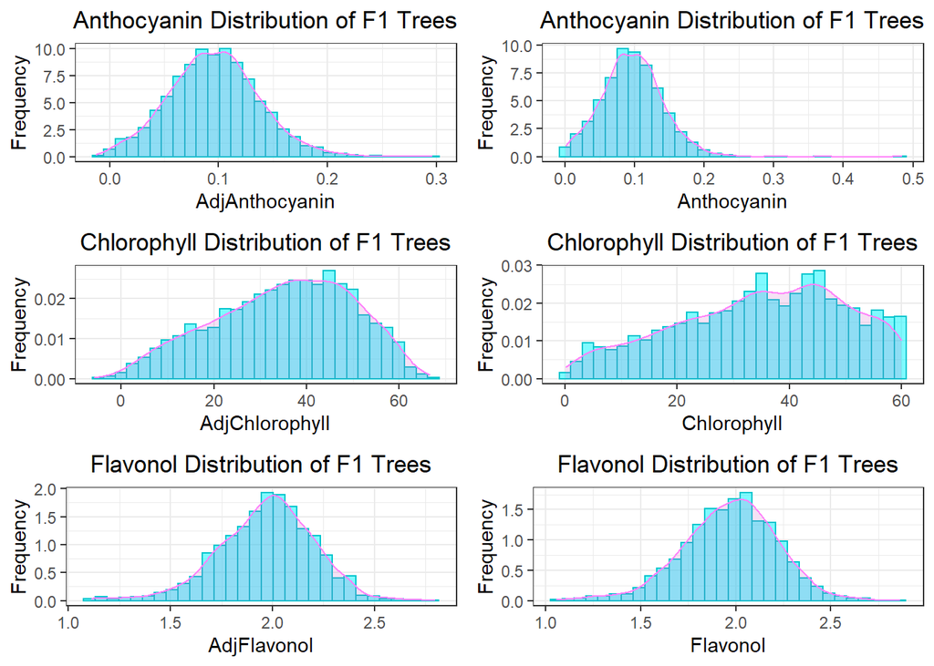

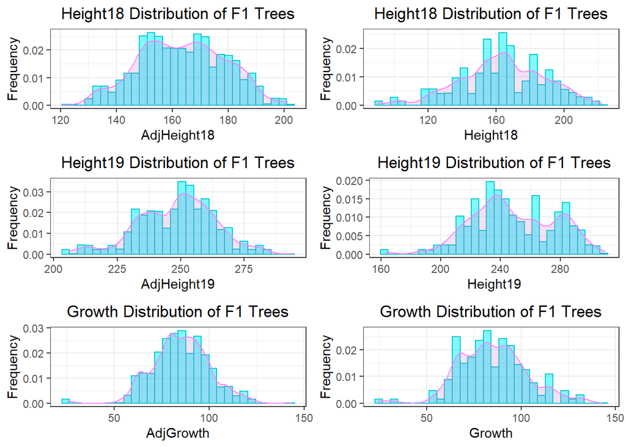

Measure comparisons for Rows before and after data adjustment

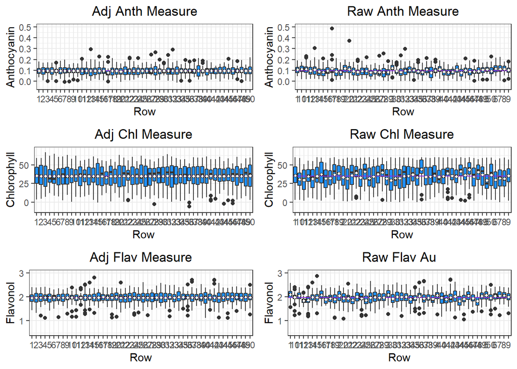

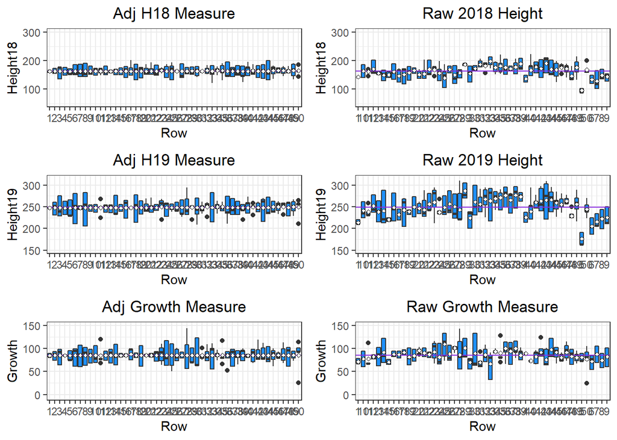

Measure comparisons for Columns before and after adjustment

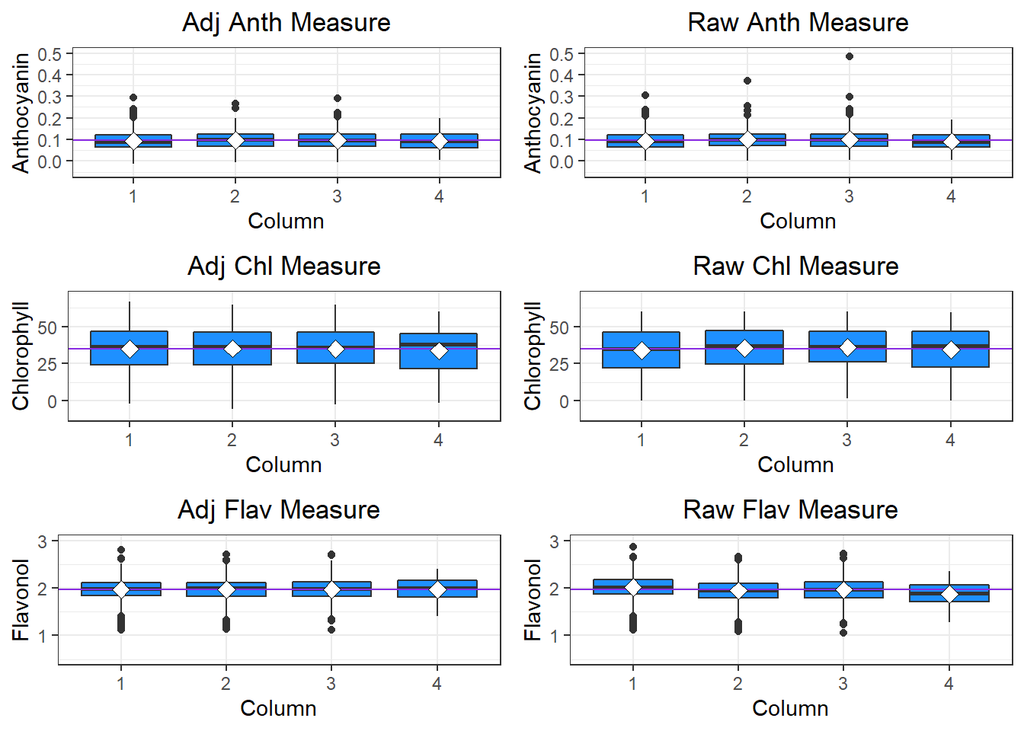

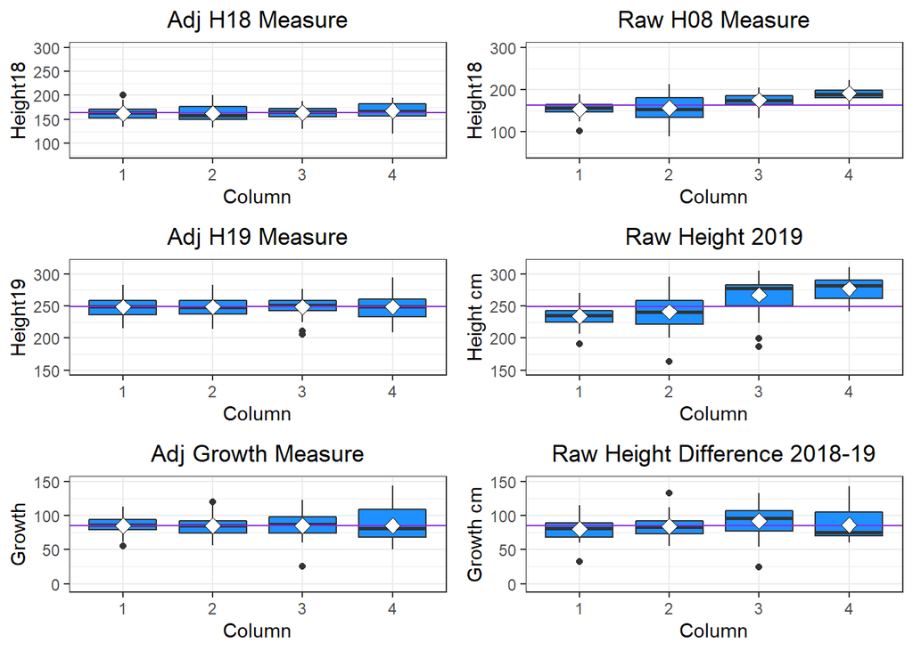

Comparison of measurement heatmaps before and after adjustment

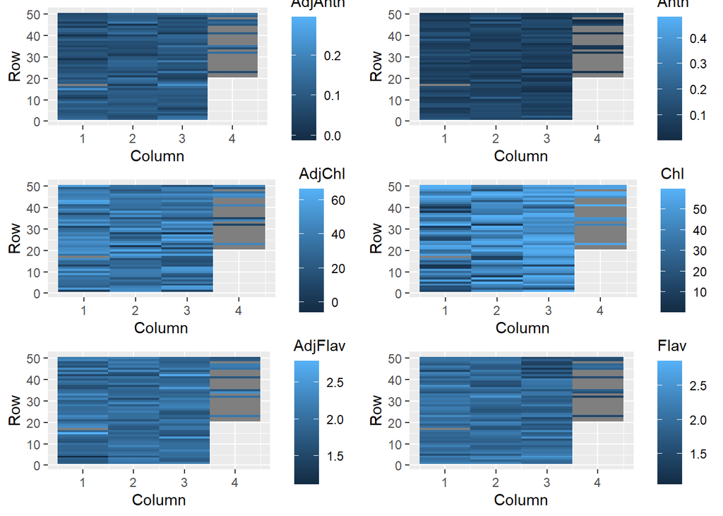

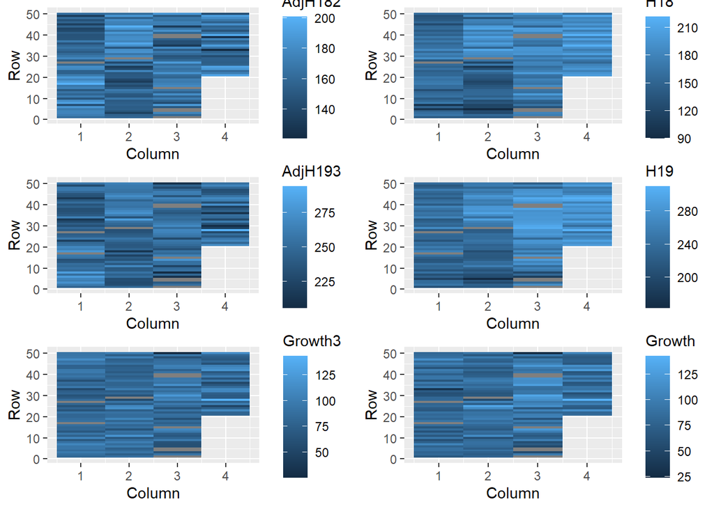

Comparisons for height differences before and after data adjustment

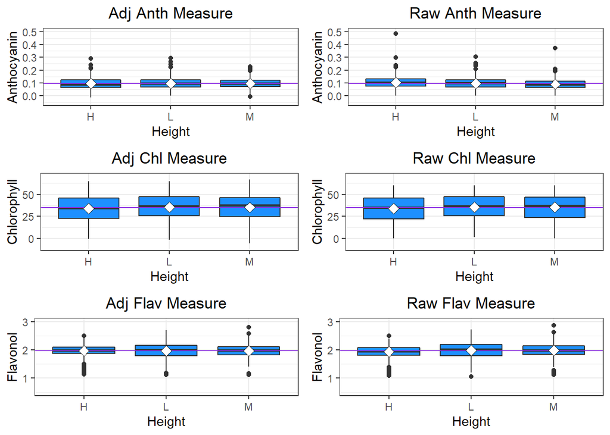

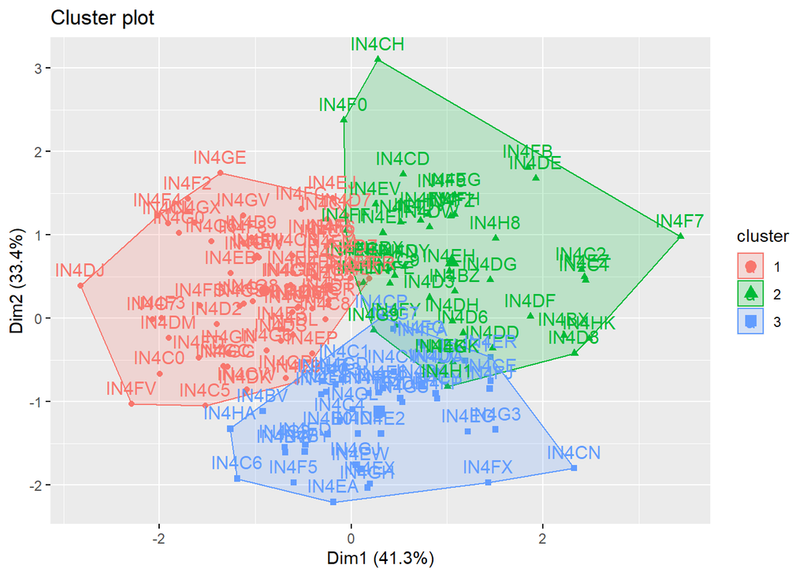

```
## dbscan Pts=159 MinPts=3 eps=0.45
##        0   1 2 3
## border 4   0 1 0
## seed   0 146 4 4
## total  4 146 5 4
```

```
##   [1] 1 1 1 1 1 1 1 1 2 1 1 1 1 1 1 1 1 1 1 1 1 1 1 1 1 1 1 1 1 1 3 1 1 1 1 1 1
##  [38] 1 1 1 1 1 2 1 1 1 1 3 1 1 1 1 1 1 1 1 1 1 1 1 1 1 1 1 1 1 1 1 1 1 1 1 1 1
##  [75] 1 1 1 1 1 3 1 0 1 1 1 1 1 1 1 1 1 1 1 2 0 1 1 1 1 1 1 2 1 2 1 1 1 1 1 1 1
## [112] 1 1 1 1 1 1 1 1 1 1 1 1 1 1 1 1 1 1 1 1 1 1 1 1 1 1 1 1 1 1 1 1 1 1 3 1 1
## [149] 1 1 1 0 1 1 1 1 1 0 1
```

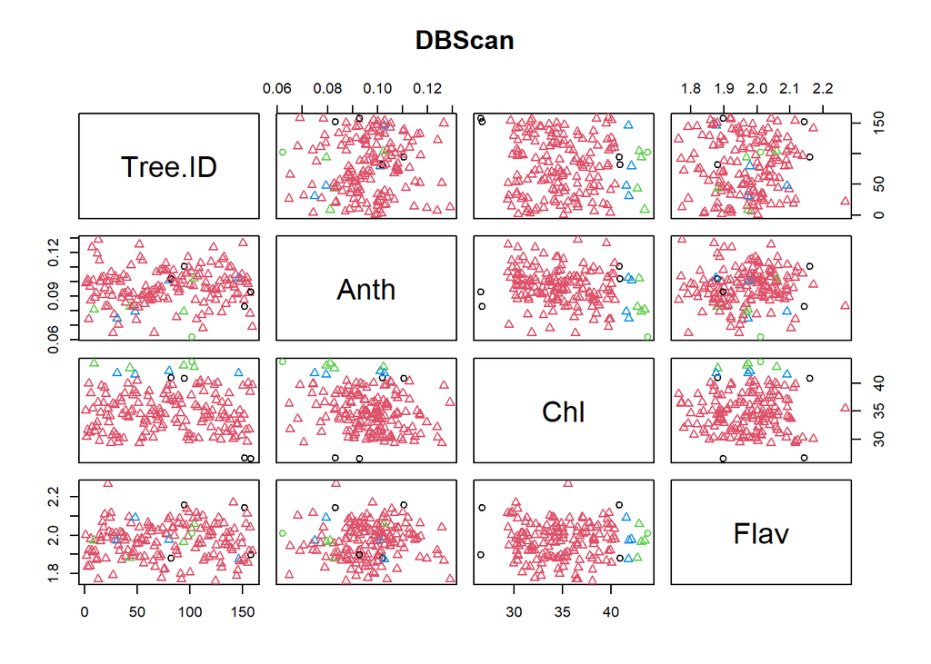

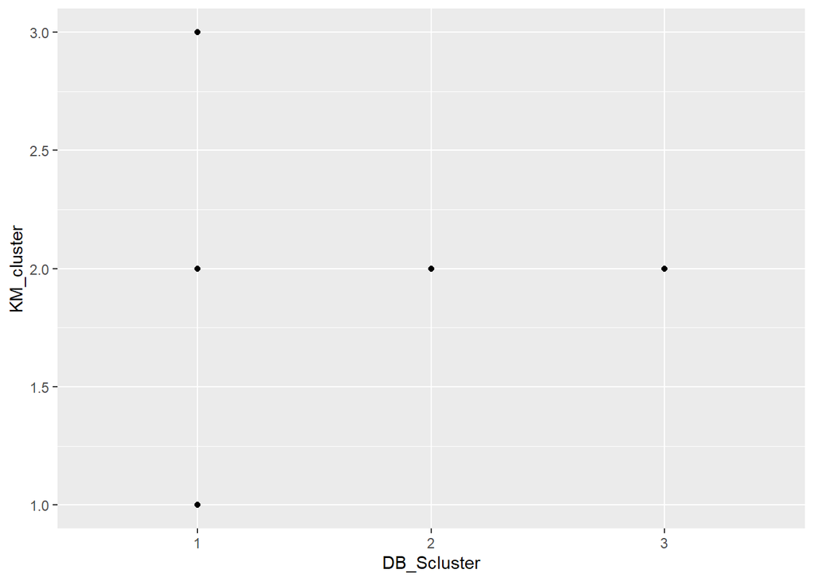

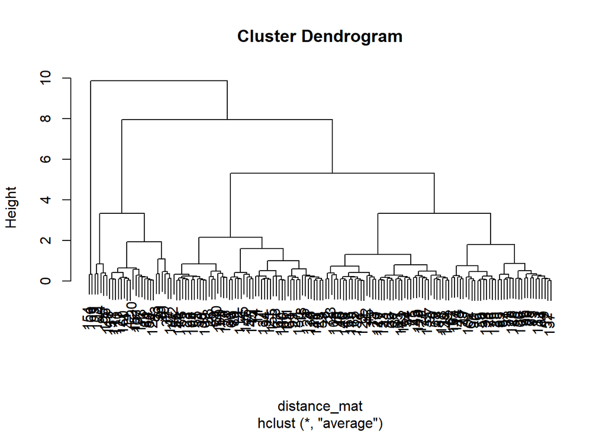

```
## fit
##   1   2   3
## 130  27   2
```

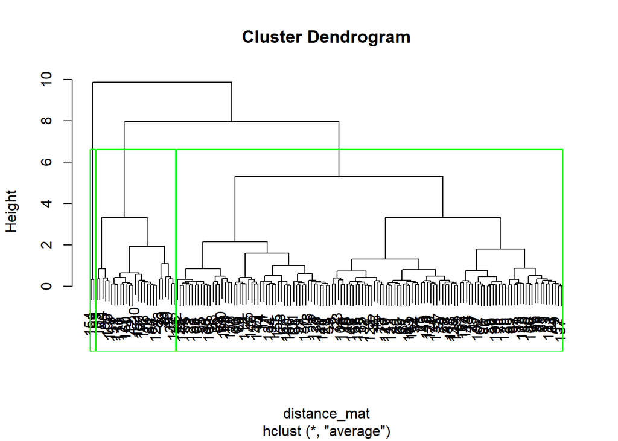

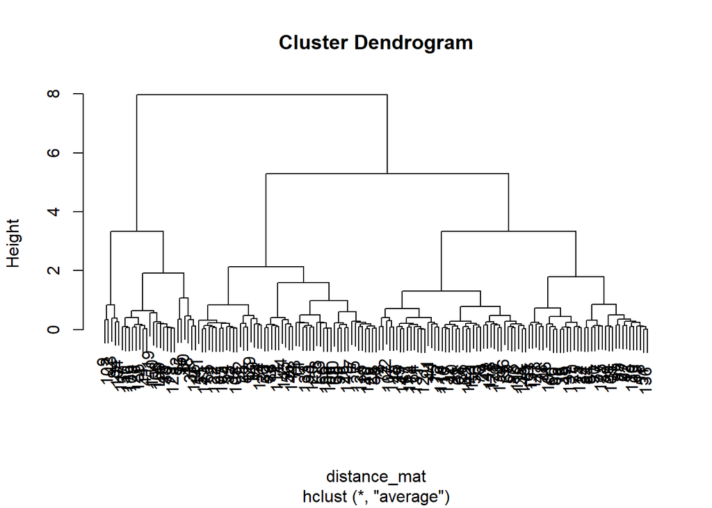

```
## fit
##  1  2  3
## 78 52 27
```

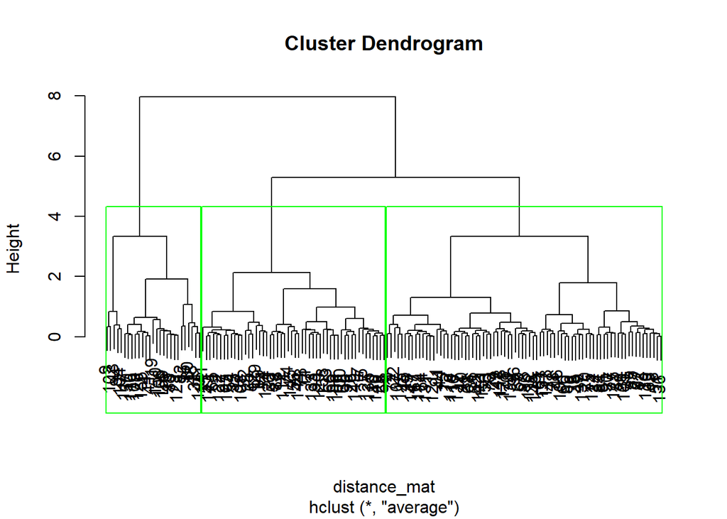

```
##   cluster  n
## 1       1 78
## 2       2 52
## 3       3 27
```

```
##             DB_Scluster KM_cluster H_cluster
## DB_Scluster         1.0          0       0.4
## KM_cluster          0.0          1       0.0
## H_cluster           0.4          0       1.0
```

[figure not shown]

```
## Analysis of Variance Table
##
## Response: tab3$DB_Scluster
##                  Df  Sum Sq Mean Sq F value    Pr(>F)
## tab3$KM_cluster   1  0.0257  0.0257  0.2401    0.6248
## tab3$H_cluster    1  3.6066  3.6066 33.6790 3.658e-08 ***
## Residuals       152 16.2774  0.1071
## ---
## Signif. codes:  0 '***' 0.001 '**' 0.01 '*' 0.05 '.' 0.1 ' ' 1
```

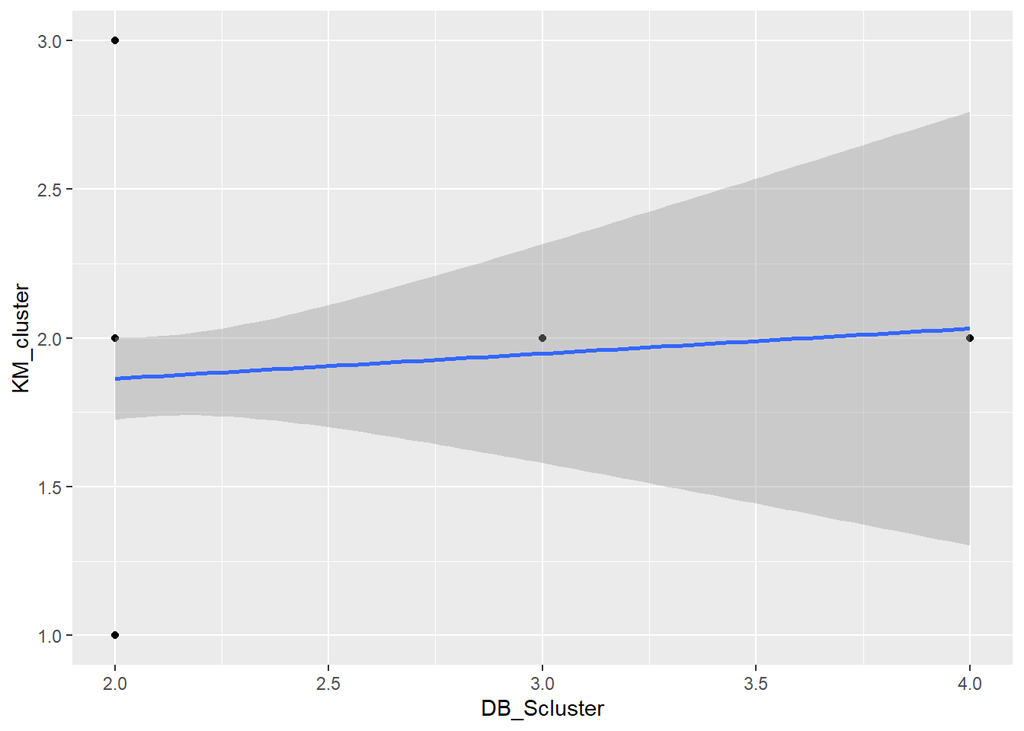

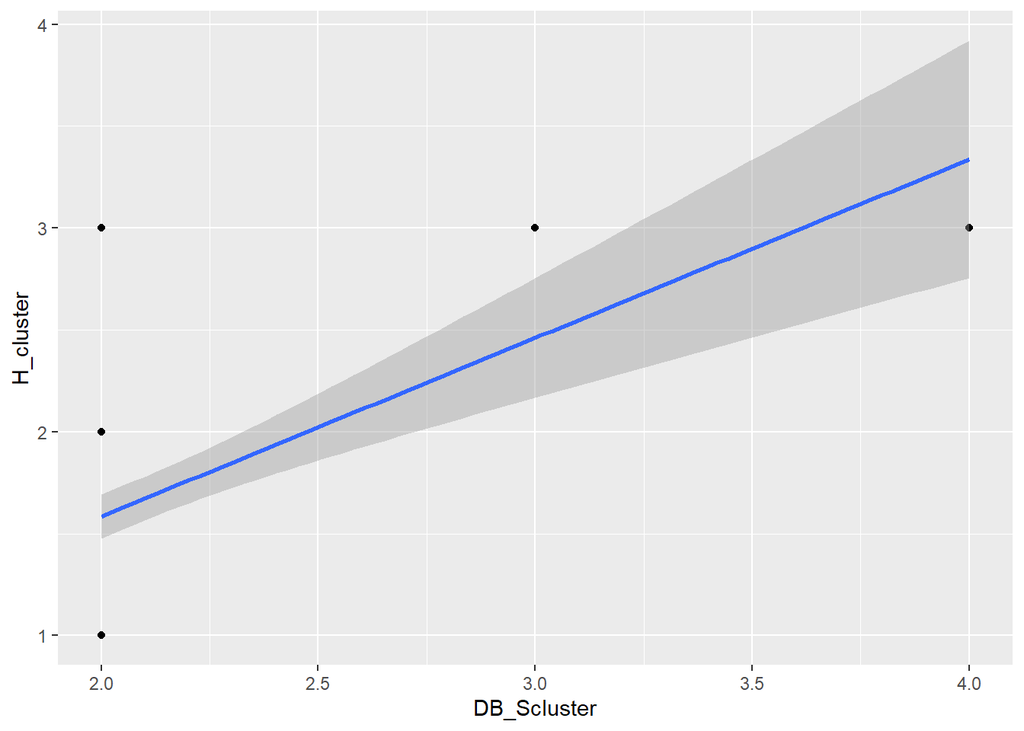

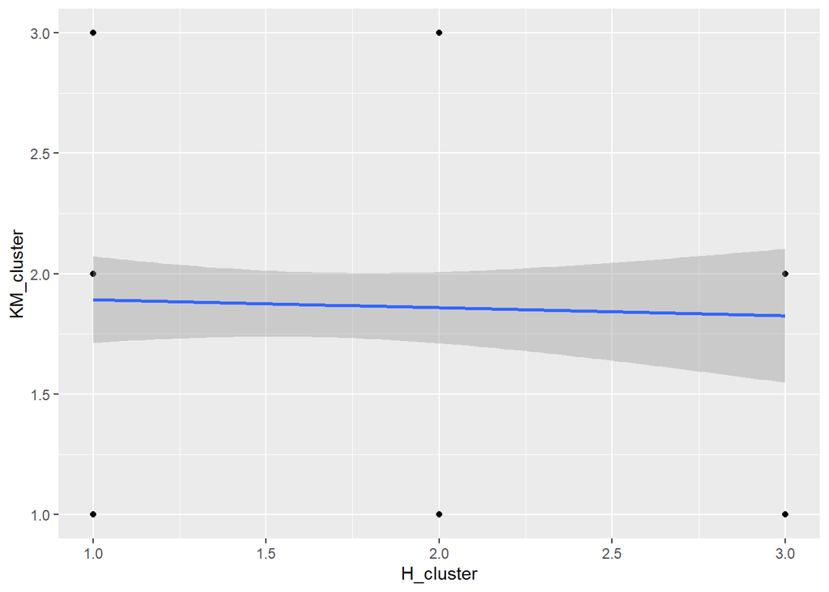